# Module 5. Modelling covariance and choosing a model

Answer key

```r
source(here::here("R", "setup.R"))
walk <- load_walk()
```

**WarningSimulated data**

All examples use simulated data from fictional studies. Results illustrate methods; they are not empirical findings.

This answer key gives complete, executed solutions to the Module 5 workbook, with model answers to the written questions and marking notes.

```r
sched <- c(0, 1, 3, 6, 9, 12)
f_mean <- sbp ~ visit_f * arm
cells  <- expand.grid(visit_f = levels(walk$visit_f), arm = levels(walk$arm))
cell_w <- function(a, v) as.numeric(cells$arm == a & cells$visit_f == v)
chg12  <- function(a) cell_w(a, "12") - cell_w(a, "0")
L_dic  <- list("SP - UC" = chg12("SP") - chg12("UC"),
               "EP - UC" = chg12("EP") - chg12("UC"))
```

## 1 Guided exercises

### 1.1 Exercise 1. Residual correlation structures (LO 5.1, 5.3)

```r
walk$res_ols <- residuals(lm(f_mean, data = walk))
obs_cor <- walk |>
  select(id, visit_f, res_ols) |>
  pivot_wider(names_from = visit_f, values_from = res_ols) |>
  select(-id) |>
  cov(use = "pairwise.complete.obs") |>
  cov2cor()
round(obs_cor, 2)
```

```
#>       0    1    3    6    9   12
#> 0  1.00 0.85 0.76 0.69 0.72 0.69
#> 1  0.85 1.00 0.83 0.76 0.75 0.73
#> 3  0.76 0.83 1.00 0.76 0.74 0.74
#> 6  0.69 0.76 0.76 1.00 0.77 0.75
#> 9  0.72 0.75 0.74 0.77 1.00 0.84
#> 12 0.69 0.73 0.74 0.75 0.84 1.00
```

```r
m_cs  <- gls(f_mean, data = walk, correlation = corCompSymm(form = ~ 1 | id))
m_ar1 <- gls(f_mean, data = walk, correlation = corAR1(form = ~ visit | id))
m_exp <- gls(f_mean, data = walk,
             correlation = corExp(form = ~ month | id, nugget = TRUE))
```

```r
rho_cs  <- coef(m_cs$modelStruct$corStruct, unconstrained = FALSE)
phi_ar1 <- coef(m_ar1$modelStruct$corStruct, unconstrained = FALSE)
p_exp   <- coef(m_exp$modelStruct$corStruct, unconstrained = FALSE)
r012 <- c(CS  = unname(rho_cs),
          AR1 = unname(phi_ar1^5),
          EXP = (1 - p_exp[["nugget"]]) * exp(-12 / p_exp[["range"]]),
          observed = obs_cor["0", "12"])
round(r012, 3)
```

```
#>       CS      AR1      EXP observed
#>    0.793    0.390    0.709    0.685
```

**Model answers.**

1. The observed correlation between baseline and month 12 is 0.69. The exponential model with nugget gives 0.71, closest to the observed value; compound symmetry gives 0.79, too high because it ignores the decline with lag; AR(1) gives 0.39 ($0.83^5$), much too low because its correlations decay geometrically towards zero.
2. AR(1) is defined on the integer positions of the measurements. `visit` (1 to 6) gives those positions and keeps them correct when a visit is missed; `month` is continuous and irregular. For actual times, use `corExp()` or `corCAR1()`.
3. The range is 60.4 months. Without a random intercept, the single exponential has to reproduce both the stable person-level component (correlations that stay near 0.7 over a year) and the short-term serial component. It can only do this by decaying very slowly; the nugget (0.14) takes care of the measurement error.

*Marking notes.* Accept AR(1) correlations computed for visit 1 to 6 as five steps. A common error is to use `phi^12`, treating months as steps; give partial credit if the reasoning about geometric decay is correct. Another is computing `obs_cor` on raw `sbp` rather than residuals; the values are then somewhat higher.

### 1.2 Exercise 2. The marginal covariance of a random intercept and slope model (LO 5.3)

```r
m_prim <- lmer(sbp ~ visit_f * arm + (1 + month | id), data = walk, control = lmer_ctrl)
G  <- as.matrix(VarCorr(m_prim)$id)
s2 <- sigma(m_prim)^2
Z  <- cbind(1, sched)
V  <- Z %*% G %*% t(Z) + diag(s2, length(sched))
dimnames(V) <- list(sched, sched)
round(V, 1)
```

```
#>        0     1     3     6     9    12
#> 0  184.7 151.5 148.4 143.6 138.9 134.2
#> 1  151.5 181.8 147.7 143.8 140.0 136.2
#> 3  148.4 147.7 177.9 144.2 142.1 140.1
#> 6  143.6 143.8 144.2 176.4 145.3 145.9
#> 9  138.9 140.0 142.1 145.3 180.1 151.8
#> 12 134.2 136.2 140.1 145.9 151.8 189.2
```

```r
round(cov2cor(V), 2)
```

```
#>       0    1    3    6    9   12
#> 0  1.00 0.83 0.82 0.80 0.76 0.72
#> 1  0.83 1.00 0.82 0.80 0.77 0.73
#> 3  0.82 0.82 1.00 0.81 0.79 0.76
#> 6  0.80 0.80 0.81 1.00 0.82 0.80
#> 9  0.76 0.77 0.79 0.82 1.00 0.82
#> 12 0.72 0.73 0.76 0.80 0.82 1.00
```

```r
all.equal(V, implied_cov_lmer(m_prim, sched), check.attributes = FALSE)
```

```
#> [1] TRUE
```

```r
var12 <- G[1, 1] + 2 * G[1, 2] * 12 + G[2, 2] * 12^2 + s2
c(by_hand = var12, from_V = V["12", "12"])
```

```
#> by_hand  from_V
#>   189.2   189.2
```

**Model answers.**

1. The implied variance is 184.7 mmHg² at baseline and 189.2 at month 12. Because $\operatorname{Var}(y_{it}) = \tau_0^2 + 2\tau_{01}t + \tau_1^2t^2 + \sigma^2$ with a negative covariance $\tau_{01} = -1.57$, the variance first falls slightly (minimum near $t = -\tau_{01}/\tau_1^2 = 5.4$ months) and then rises as the $\tau_1^2t^2$ term grows.
2. The implied correlation between months 0 and 1 is 0.83, below the observed 0.85. The model has no serial correlation, so it cannot make measurements one month apart more alike than the random intercept and slope allow. It misses the short-term serial correlation.

*Marking notes.* The most common error is forgetting `diag(s2, 6)` (giving $ZGZ^\top$ only), or using `VarCorr()` standard deviations instead of variances.

### 1.3 Exercise 3. Heterogeneous variances and REML comparisons (LO 5.2, 5.4)

```r
m_exp_het <- update(m_exp, weights = varIdent(form = ~ 1 | visit_f))
het_r <- coef(m_exp_het$modelStruct$varStruct, unconstrained = FALSE, allCoef = TRUE)
round(het_r, 3)
```

```
#>     0     1     3     6     9    12
#> 1.000 1.011 1.026 1.063 1.033 1.006
```

```r
a_het <- anova(m_exp, m_exp_het)
a_het
```

```
#>           Model df   AIC   BIC logLik   Test L.Ratio p-value
#> m_exp         1 21 13267 13383  -6613
#> m_exp_het     2 26 13273 13417  -6611 1 vs 2   4.109  0.5339
```

```r
m_exp_lin <- gls(sbp ~ month * arm, data = walk,
                 correlation = corExp(form = ~ month | id, nugget = TRUE))
anova(m_exp_lin, m_exp)
```

```
#>           Model df   AIC   BIC logLik   Test L.Ratio p-value
#> m_exp_lin     1  9 13404 13453  -6693
#> m_exp         2 21 13267 13383  -6613 1 vs 2   160.4  <.0001
```

```r
a_ml <- anova(update(m_exp_lin, method = "ML"), update(m_exp, method = "ML"))
a_ml
```

```
#>                                  Model df   AIC   BIC logLik   Test L.Ratio
#> update(m_exp_lin, method = "ML")     1  9 13400 13450  -6691
#> update(m_exp, method = "ML")         2 21 13290 13407  -6624 1 vs 2   133.8
#>                                  p-value
#> update(m_exp_lin, method = "ML")
#> update(m_exp, method = "ML")      <.0001
```

**Model answers.**

1. No. The SD ratios range from 1.000 to 1.063 and the LRT on REML fits (same mean model) gives $\chi^2_5 = 4.11$, p = 0.534.
2. nlme warns that the fitted objects have different fixed effects and that REML comparisons are not meaningful. REML maximises the likelihood of error contrasts that depend on $X$, so REML likelihoods for different mean models are not comparable.
3. Only the ML comparison is valid. It gives $\chi^2_{12} = 133.8$, p < 0.001: the categorical-time mean model fits much better than linear time, because the true trajectories level off after about six months.

*Marking notes.* Accept “the REML comparison is not valid” without the error-contrast explanation for partial credit. Students who report the REML LRT in (b) as evidence should lose the marks for (iii).

### 1.4 Exercise 4. A boundary test for the clinic variance (LO 5.5)

```r
m_clinic <- lmer(sbp ~ visit_f * arm + (1 + month | id) + (1 | clinic),
                 data = walk, control = lmer_ctrl)
lt <- lr_test(m_prim, m_clinic)
lt$p_mixture <- p_boundary_mixture(lt$chisq)
lt
```

```
#>   logLik_0 logLik_1 chisq df        p p_mixture
#> 1    -6624    -6619 10.68  1 0.001085 0.0005426
```

**Model answers.**

1. The null value (variance 0) lies on the boundary of the parameter space. Under the null, the estimated variance is zero about half the time, and the LR statistic is then exactly zero, so its null distribution is a 50:50 mixture of a point mass at zero and $\chi^2_1$ (Self and Liang 1987). Comparing with $\chi^2_1$ alone overstates the p-value. Here the naive p-value is 0.0011 and the mixture p-value 0.0005, exactly half.
2. Statistically, the clinic variance is clearly non-zero (LR = 10.7, estimated clinic SD 3.1 mmHg). By design, participants were recruited and randomised within clinics, so clinic is a natural grouping factor (a stratification factor should usually be reflected in the analysis). A good answer also notes that the treatment estimates barely change, so including or excluding it is not critical for the estimand, and that this should be prespecified.

### 1.5 Exercise 5. A singular fit in a small sample (LO 5.5)

```r
set.seed(8)
small <- filter(walk, id %in% sample(unique(walk$id), 30))
m_small <- lmer(sbp ~ month * arm + (1 + month | id), data = small, control = lmer_ctrl)
```

```
#> boundary (singular) fit: see help('isSingular')
```

```r
VarCorr(m_small)
```

```
#>  Groups   Name        Std.Dev. Corr
#>  id       (Intercept) 13.370
#>           month        0.106   -1.00
#>  Residual              5.780
```

```r
isSingular(m_small)
```

```
#> [1] TRUE
```

Trying several seeds shows that most samples of 30 give a regular fit:

```r
sing <- sapply(1:20, function(s) {
  set.seed(s)
  d <- filter(walk, id %in% sample(unique(walk$id), 30))
  isSingular(suppressMessages(lmer(sbp ~ month * arm + (1 + month | id), data = d,
                                   control = lmer_ctrl)))
})
mean(sing)
```

```
#> [1] 0.05
```

```r
m_small_unc <- lmer(sbp ~ month * arm + (1 + month || id), data = small, control = lmer_ctrl)
```

```
#> boundary (singular) fit: see help('isSingular')
```

```r
m_small_ri  <- lmer(sbp ~ month * arm + (1 | id), data = small, control = lmer_ctrl)
small_cmp <- bind_rows(lapply(list(correlated = m_small, uncorrelated = m_small_unc,
                                   intercept_only = m_small_ri), function(m) {
  s <- coef(summary(m))["month:armEP", ]
  data.frame(estimate = s[["Estimate"]], se = s[["Std. Error"]], singular = isSingular(m))
}), .id = "random_effects")
small_cmp
```

```
#>   random_effects estimate     se singular
#> 1     correlated   -1.050 0.3561     TRUE
#> 2   uncorrelated   -1.043 0.3549     TRUE
#> 3 intercept_only   -1.043 0.3549    FALSE
```

**Model answers.**

1. With seed 8 the correlation between random intercept and slope is estimated at -1, a boundary value; the 2 × 2 covariance matrix has rank one. In 5% of 20 seeds the fit was singular.
2. No. The slope SD in the full data is clearly positive (true value 0.35 mmHg/month); with 30 participants there is too little information to estimate the covariance matrix, and boundary estimates are common even when the true parameters are interior.
3. The estimate of `month:armEP` hardly changes between specifications (-1.05, -1.04, -1.04), and the standard errors are similar. In this sample the uncorrelated model is also singular (the slope variance is estimated as zero), so the intercept-only model is the only non-singular option. Reasonable answers: report the simpler non-singular model (uncorrelated or intercept-only, whichever is not singular) and state that the full model was singular; or keep the prespecified model and report that the conclusions do not change. Either is acceptable if justified and transparent.

## 2 Independent exercises

### 2.1 Exercise 6. Choose and defend a covariance model (LO 5.1, 5.4, 5.6)

```r
w4 <- filter(walk, clinic %in% 1:4)
c(participants = n_distinct(w4$id), observations = nrow(w4))
```

```
#> participants observations
#>          180          946
```

```r
w4$res_ols <- residuals(lm(f_mean, data = w4))
obs_cor4 <- w4 |> select(id, visit_f, res_ols) |>
  pivot_wider(names_from = visit_f, values_from = res_ols) |> select(-id) |>
  cov(use = "pairwise.complete.obs") |>
  cov2cor()

mods4 <- list(
  "Compound symmetry"   = gls(f_mean, data = w4, correlation = corCompSymm(form = ~ 1 | id)),
  "Exponential + nugget" = gls(f_mean, data = w4,
                               correlation = corExp(form = ~ month | id, nugget = TRUE)),
  "Unstructured"        = gls(f_mean, data = w4, correlation = corSymm(form = ~ visit | id),
                              weights = varIdent(form = ~ 1 | visit_f)),
  "Random intercept + slope" = lme(f_mean, random = ~ 1 + month | id, data = w4),
  "Random intercept + exponential" = lme(f_mean, random = ~ 1 | id, data = w4,
                               correlation = corExp(form = ~ month | id, nugget = TRUE)))
cmp4 <- data.frame(model = names(mods4),
                   n_cov = sapply(mods4, function(m) attr(logLik(m), "df")) - 18,
                   AIC = sapply(mods4, AIC), BIC = sapply(mods4, BIC), row.names = NULL) |>
  mutate(dAIC = AIC - min(AIC), dBIC = BIC - min(BIC))
knitr::kable(cmp4, digits = 1)
```

| model | n_cov | AIC | BIC | dAIC | dBIC |
| --- | --- | --- | --- | --- | --- |
| Compound symmetry | 2 | 6648 | 6744 | 39.8 | 30.1 |
| Exponential + nugget | 3 | 6616 | 6718 | 8.3 | 3.5 |
| Unstructured | 21 | 6623 | 6811 | 14.9 | 97.1 |
| Random intercept + slope | 4 | 6629 | 6735 | 21.3 | 21.3 |
| Random intercept + exponential | 4 | 6608 | 6714 | 0.0 | 0.0 |

The heatmap uses the implied-covariance function from the notes.

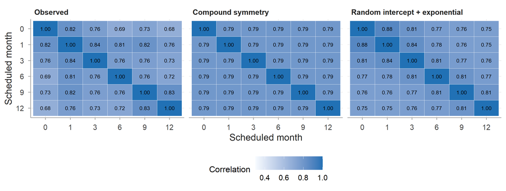

Clinics 1 to 4: observed residual correlations and those implied by two candidate models.

```r
implied_cov <- function(model, times = sched) {
  k <- length(times); C <- diag(k)
  cs <- model$modelStruct$corStruct
  if (!is.null(cs)) {
    if (inherits(cs, "corCompSymm")) {
      C <- matrix(coef(cs, unconstrained = FALSE), k, k); diag(C) <- 1
    } else if (inherits(cs, c("corAR1", "corARMA"))) {
      C <- coef(cs, unconstrained = FALSE)^abs(outer(1:k, 1:k, "-"))
    } else if (inherits(cs, "corExp")) {
      p <- coef(cs, unconstrained = FALSE)
      nug <- if ("nugget" %in% names(p)) p[["nugget"]] else 0
      C <- (1 - nug) * exp(-abs(outer(times, times, "-")) / p[["range"]]); diag(C) <- 1
    } else if (inherits(cs, "corSymm")) {
      C[lower.tri(C)] <- coef(cs, unconstrained = FALSE); C <- C + t(C) - diag(k)
    }
  }
  vs <- model$modelStruct$varStruct
  s <- if (is.null(vs)) rep(1, k) else
    coef(vs, unconstrained = FALSE, allCoef = TRUE)[as.character(times)]
  V <- model$sigma^2 * diag(s) %*% C %*% diag(s)
  if (inherits(model, "lme")) {
    G <- as.matrix(getVarCov(model)); Z <- cbind(1, times)[, seq_len(ncol(G)), drop = FALSE]
    V <- Z %*% G %*% t(Z) + V
  }
  dimnames(V) <- list(times, times); V
}
mat_long <- function(M, label) {
  data.frame(row = factor(rep(rownames(M), ncol(M)), levels = rownames(M)),
             col = factor(rep(colnames(M), each = nrow(M)), levels = colnames(M)),
             value = as.vector(M), model = label)
}
bind_rows(mat_long(obs_cor4, "Observed"),
          mat_long(cov2cor(implied_cov(mods4[["Compound symmetry"]])), "Compound symmetry"),
          mat_long(cov2cor(implied_cov(mods4[["Random intercept + exponential"]])),
                   "Random intercept + exponential")) |>
  mutate(model = factor(model, levels = unique(model))) |>
  ggplot(aes(col, row, fill = value)) + geom_tile(colour = "white") +
  geom_text(aes(label = sprintf("%.2f", value)), size = 2.4) +
  scale_fill_gradient(low = "#F7FBFF", high = "#2171B5", limits = c(0.3, 1),
                      name = "Correlation") +
  scale_y_discrete(limits = rev) + facet_wrap(~ model) +
  labs(x = "Scheduled month", y = "Scheduled month") +
  theme(panel.grid = element_blank())
```

**Model answer.** In clinics 1 to 4 (180 participants) the lowest AIC belongs to the Random intercept + exponential model and the lowest BIC to the Random intercept + exponential model. A justification might read: “The covariance model must describe a stable between-participant component and correlation that declines with time between visits, and must handle irregular visit times. A random intercept with exponential serial correlation in actual time and a nugget does all three with four covariance parameters. It had the lowest AIC and BIC of the candidates, its implied correlations match the observed pattern, and it is far more parsimonious than the unstructured covariance, which would be fragile with about 45 participants per arm at month 12. A random intercept and slope model will be reported as a sensitivity analysis.”

*Marking notes.* Award marks for: same mean model in all fits; REML used; a table with AIC and BIC; a heatmap; a justification that refers both to the statistics and to substantive features (irregular times, parsimony, sample size). Do not require a particular final choice; with a smaller sample, BIC may favour simpler structures than in the full data. Penalise choosing the unstructured model only “because it has the highest log-likelihood”.

### 2.2 Exercise 7. Does the covariance model change the answer? (LO 5.6)

```r
eff4 <- bind_rows(lapply(names(mods4), function(nm) {
  m <- mods4[[nm]]
  e <- if (inherits(m, "gls")) emmeans(m, ~ visit_f * arm, mode = "df.error") else
    emmeans(m, ~ visit_f * arm)
  s <- summary(contrast(e, L_dic["EP - UC"]), infer = TRUE)
  data.frame(model = nm, estimate = s$estimate, se = s$SE,
             lower = s$lower.CL, upper = s$upper.CL)
}))
knitr::kable(eff4, digits = 2)
```

| model | estimate | se | lower | upper |
| --- | --- | --- | --- | --- |
| Compound symmetry | -6.35 | 1.76 | -9.80 | -2.89 |
| Exponential + nugget | -6.46 | 2.06 | -10.50 | -2.42 |
| Unstructured | -6.39 | 1.98 | -10.28 | -2.49 |
| Random intercept + slope | -6.46 | 2.01 | -10.41 | -2.52 |
| Random intercept + exponential | -6.46 | 1.92 | -10.22 | -2.70 |

**Model answer.** Across the five models the EP versus UC difference in mean change ranges from -6.46 to -6.35 mmHg, and the standard error from 1.76 to 2.06. The point estimate depends little on the covariance model. Compound symmetry gives the smallest standard error (1.76), which is likely too small because it assumes that baseline and month 12 are as highly correlated as adjacent visits. The conclusion (a clear reduction in the enhanced programme relative to usual care) is the same under every model.

### 2.3 Exercise 8. Variance by arm (LO 5.2, 5.4)

```r
m_riexp     <- lme(f_mean, random = ~ 1 | id, data = walk,
                   correlation = corExp(form = ~ month | id, nugget = TRUE))
m_riexp_arm <- update(m_riexp, weights = varIdent(form = ~ 1 | arm))
arm_r <- coef(m_riexp_arm$modelStruct$varStruct, unconstrained = FALSE, allCoef = TRUE)
round(arm_r, 3)
```

```
#>    EP    SP    UC
#> 1.000 1.011 1.079
```

```r
a_arm <- anova(m_riexp, m_riexp_arm)
a_arm
```

```
#>             Model df   AIC   BIC logLik   Test L.Ratio p-value
#> m_riexp         1 22 13255 13377  -6605
#> m_riexp_arm     2 24 13256 13388  -6604 1 vs 2   3.418  0.1811
```

*Marking notes.* A variance ratio is not on the boundary when testing equality (ratio = 1), so no mixture is needed; students who apply the mixture should lose a mark.

### 2.4 Exercise 9. Write the methods paragraph (LO 5.6)

**Model answer.** “The primary analysis used a linear mixed model with a separate mean for each arm at each scheduled visit (visit by arm interaction) and a random intercept and random slope on actual time since randomisation for each participant, with an unstructured 2 × 2 covariance matrix, fitted by REML. This covariance model was prespecified because it describes stable between-participant differences and individual trends and accommodates irregular visit times. Its adequacy was checked by comparing implied and observed correlations between visits and by the semivariogram of normalized residuals. Sensitivity analyses used an unstructured residual covariance and a random intercept with exponential serial correlation in continuous time and a nugget; the estimated differences in mean change at month 12 differed from the primary analysis by less than 0.1 mmHg.”

*Marking notes.* Look for: the mean model, the random-effects structure, the estimation method, the reason for the choice (prespecification and substantive features), how adequacy was checked, and sensitivity analyses. Numbers should match the notes.

## References

Self, Steven G., and Kung-Yee Liang. 1987. ‘Asymptotic Properties of Maximum Likelihood Estimators and Likelihood Ratio Tests Under Nonstandard Conditions’. *Journal of the American Statistical Association* 82 (398): 605–10. https://doi.org/10.1080/01621459.1987.10478472.